# **Exercise 1. Corruption and human development**

This exercise explores a dataset containing the human development index (`HDI`) and corruption perception index (`CPI`) of 173 countries across 6 different regions around the world: Americas, Asia Pacific, Eastern Europe and Central Asia (`East EU Cemt`), Western Europe (`EU W. Europe`), Middle East and North Africa and Noth Africa (`MENA`), and Sub-Saharan Africa (`SSA`). (Note: the larger `CPI` is, the less corrupted the country is perceived to be.)

First, we load the data using the following code.

```r
economist_data <- read.csv("https://raw.githubusercontent.com/nt246/NTRES6940-data-science/master/datasets/EconomistData.csv")
```

**1.1 Show the first few rows of `economist_data`.**

| X | Country | HDI.Rank | HDI | CPI | Region |
| --- | --- | --- | --- | --- | --- |
| 1 | Afghanistan | 172 | 0.398 | 1.5 | Asia Pacific |
| 2 | Albania | 70 | 0.739 | 3.1 | East EU Cemt Asia |
| 3 | Algeria | 96 | 0.698 | 2.9 | MENA |
| 4 | Angola | 148 | 0.486 | 2.0 | SSA |
| 5 | Argentina | 45 | 0.797 | 3.0 | Americas |
| 6 | Armenia | 86 | 0.716 | 2.6 | East EU Cemt Asia |

**1.2 Expore the relationship between human development index (`HDI`) and corruption perception index (`CPI`) with a scatter plot as the following.**

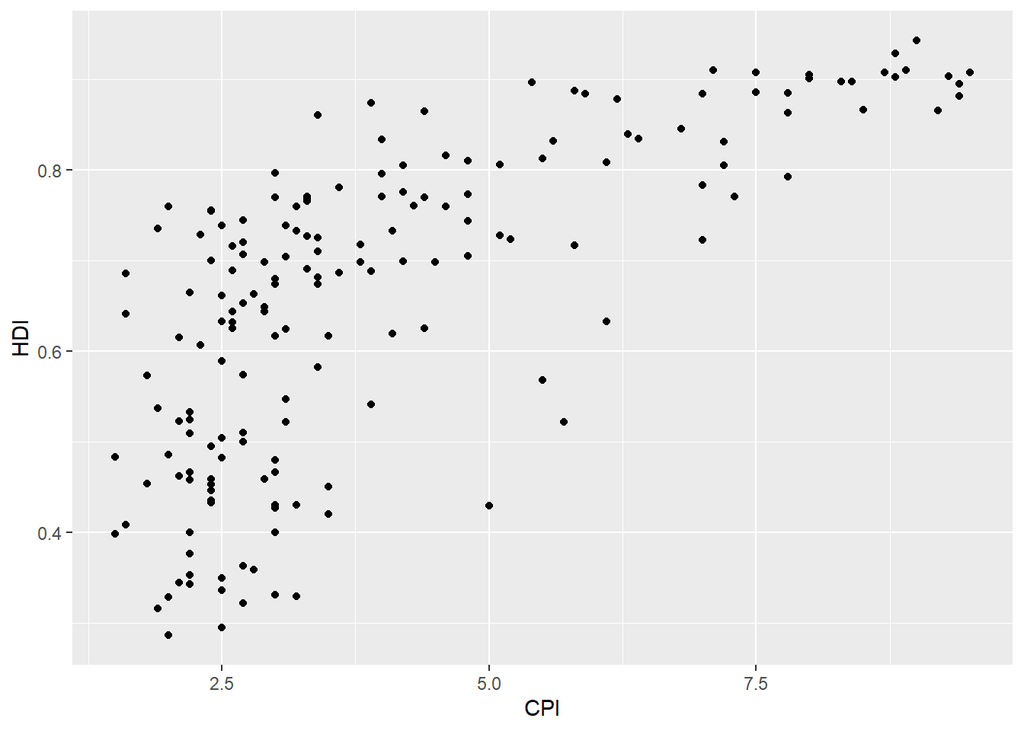

**1.3 Make the color of all points in the previous plot red**

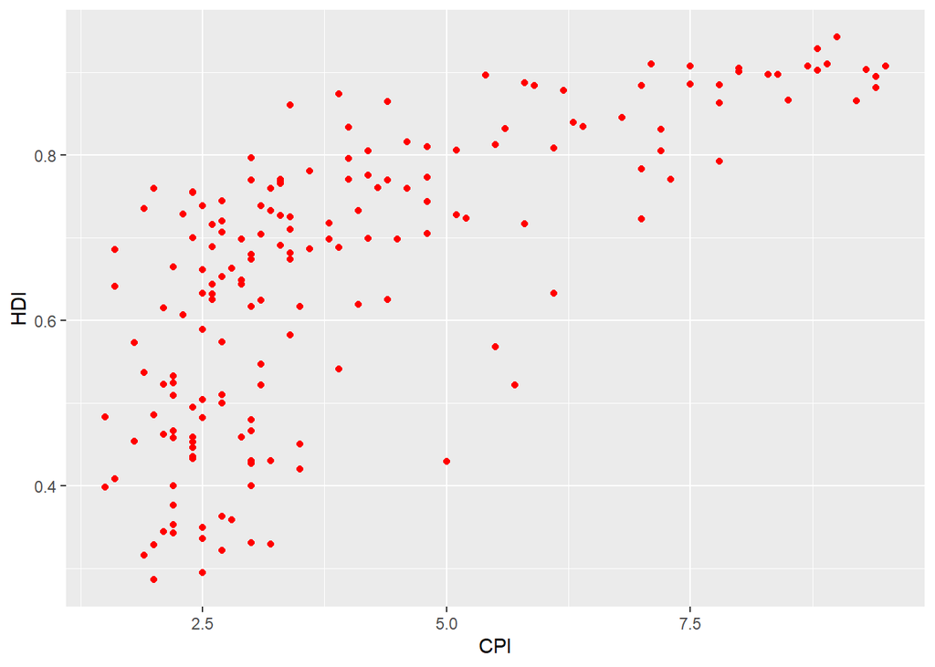

**1.4 Color the points in the previous plot according to the `Region` variable, and set the size of points to 2.**

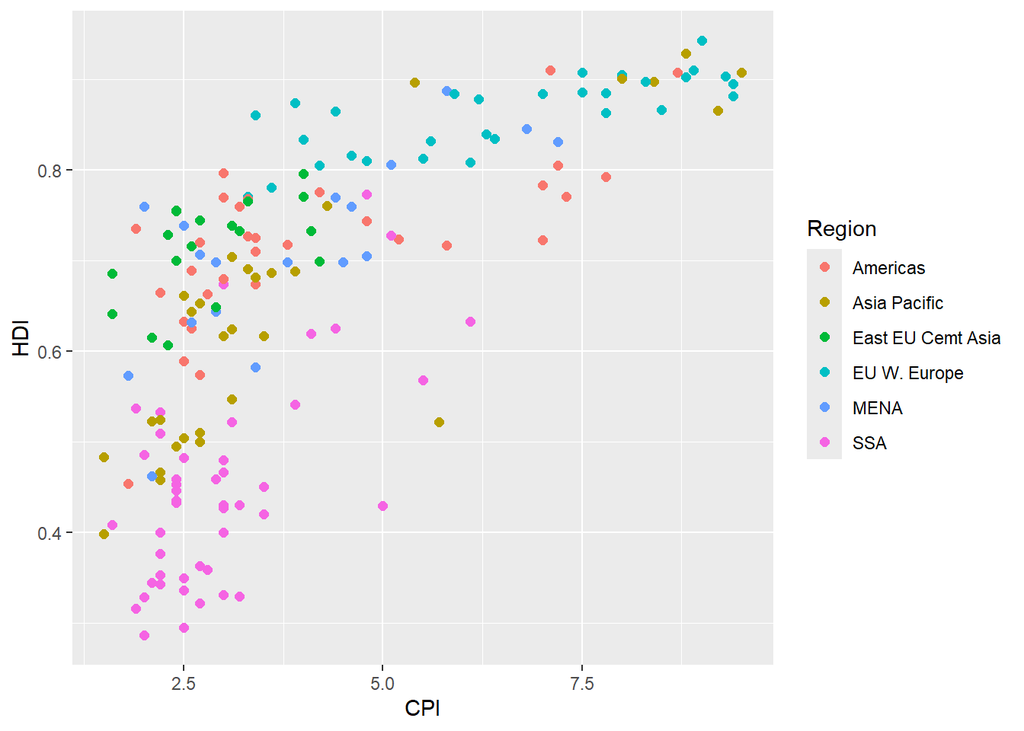

**1.5 Set the size of the points proportional to `HDI.Rank`**

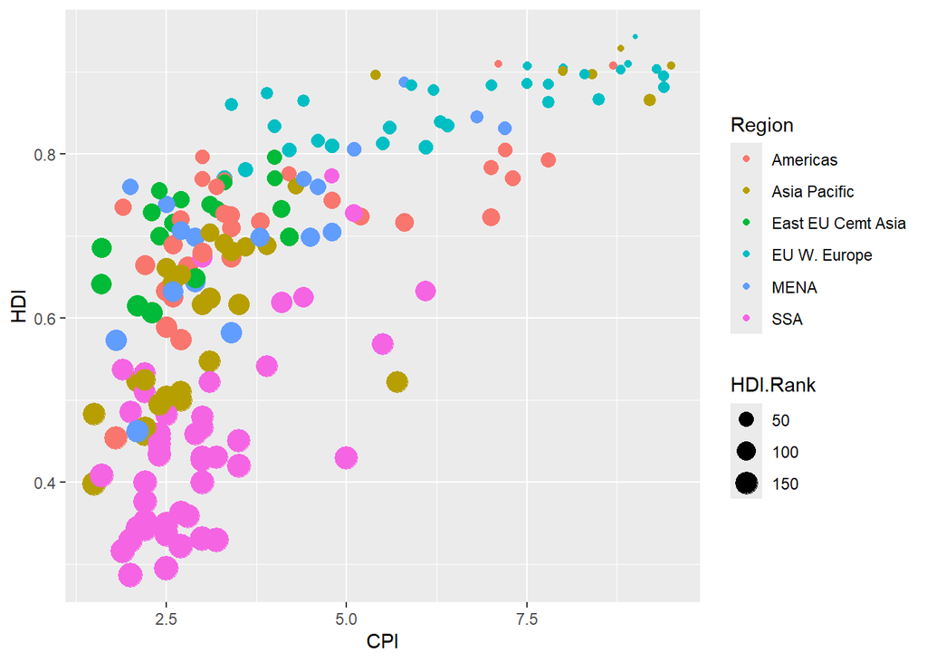

**1.6 Fit a smoothing line to all the data points in the scatter plot from Excercise 1.4**

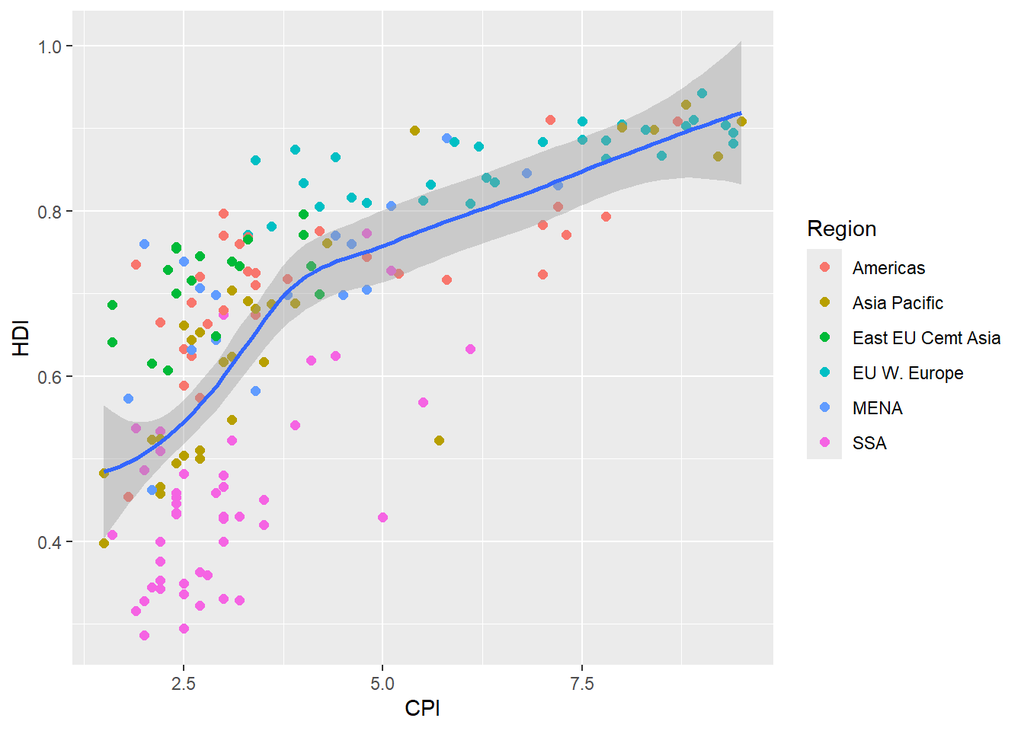

**1.7 Fit a separate straight line for each region instead, and turn off the confidence interval.**

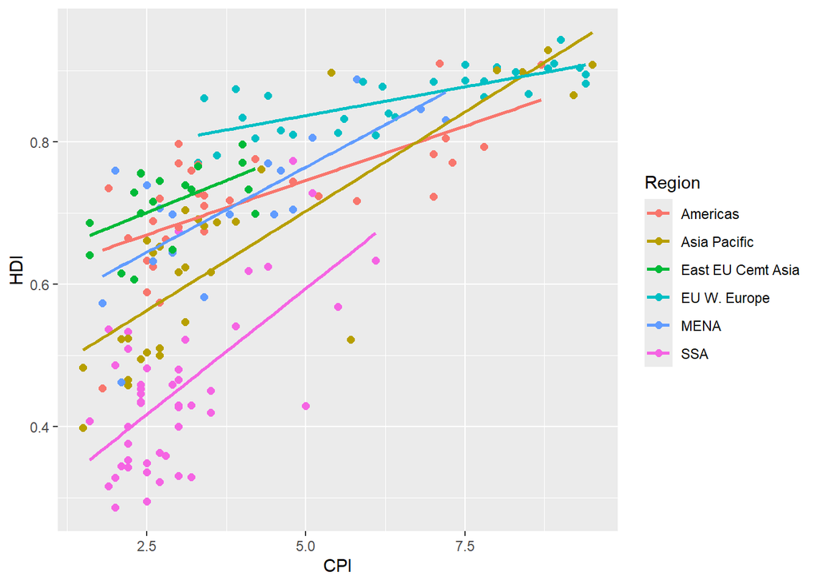

**1.8 Building on top of the previous plot, show each `Region` in a different facet.**

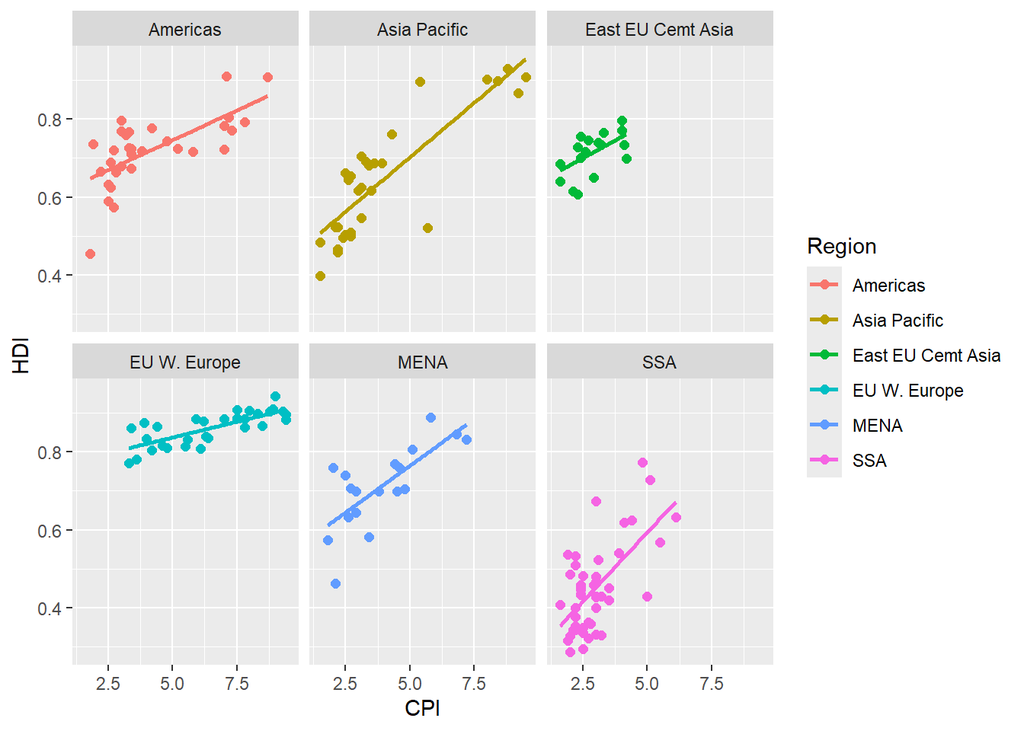

**1.9 Show the distribution of `HDI` in each region using density plot. Set the transparency to 0.5**